# Tarea2_Ricardo_Garbanzo

Ricardo Garbanzo

February 5, 2020

# 1. [20 puntos] Utilizando los datos de la tabla encuesta_brexit.csv replique el siguiente grafico y explique una a una las lineas de codigo utilizadas:

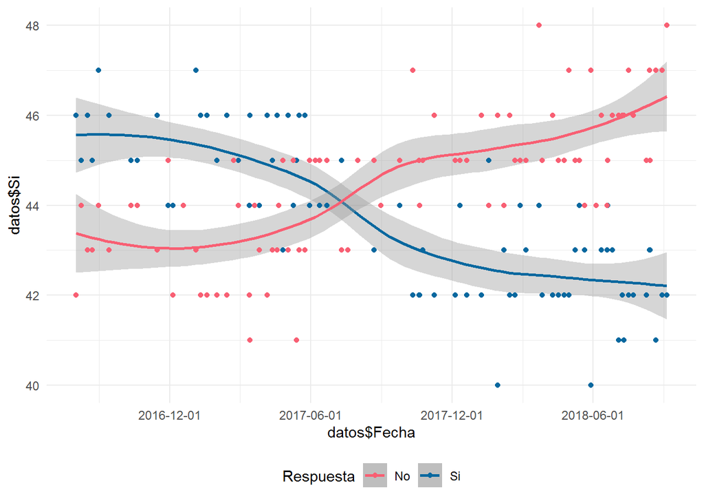

```r
datos <- read.csv("encuesta_brexit.csv", sep = ",", header = T)
library(ggplot2)
datos$Fecha <- as.Date(datos$Fecha, "%d/%m/%y")

g <- ggplot(data = datos, mapping = aes(x = datos$Fecha)) +
  geom_smooth(mapping = aes(y = datos$Si, color = "Si")) +
  geom_smooth(mapping = aes(y = datos$No, color = "No")) +
  geom_point(mapping = aes(y = datos$Si, color = "Si")) +
  geom_point(mapping = aes(y = datos$No, color = "No")) +
  scale_color_manual(values = c("#f85f73","#07689f"), name = "Respuesta") +
  scale_x_date(date_breaks = "6 month") +
  theme_minimal() +
  theme(legend.position = "bottom")
g
```

`datos <- read.csv("encuesta_brexit.csv", sep = ",", header = T)` Carga de datos

`library(ggplot2)` Carga de libreria

`datos$Fecha <- as.Date(datos$Fecha, "%d/%m/%y")` Transformacion de variable fecha en tipo DATE

`g <- ggplot(data = datos, mapping = aes(x = datos$Fecha)) +` Asignacion de plot y datos en eje x

`geom_smooth(mapping = aes(y = datos$Si, color = "Si")) +` graficar intervalo de confianza para variable si

`geom_smooth(mapping = aes(y = datos$No, color = "No")) +`graficar intervalo de confianza para variable NO

`geom_point(mapping = aes(y = datos$Si, color = "Si")) +` graficar observaciones de si en eje Y con punto

`geom_point(mapping = aes(y = datos$No, color = "No")) +`graficar observaciones de no en eje Y con punto

`scale_x_date(date_breaks = "6 month") +` se define una escala de forma manual para la variable fecha en el eje X

`theme_minimal() +` Se aplica un tema para el fondo del gráfico

`theme(legend.position = "bottom")` se configura la leyenda del grafico en la parte inferior.

# 2. [20 puntos] Utilizando los datos de la tabla IDH cantonal 2014.csv realice lo siguiente:

1. Seleccione una provincia.
2. Filtre los datos para la provincia seleccionada.
3. Realice un mapa de la provincia seleccionada en el que se pueda observar el IDC representado por colores, ademas una etiqueta debe indicar el nombre del canton asi como el valor exacto del IDC.

```r
library(dplyr)
library(sf)
```

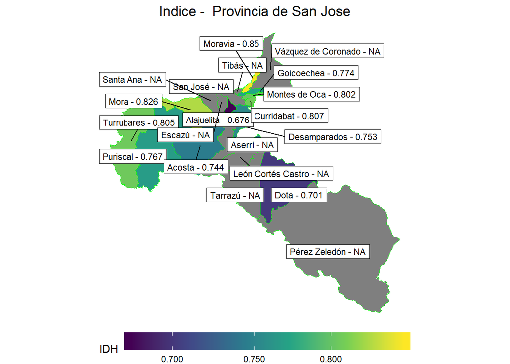

```r
library(scales)
library(ggplot2)
library(ggrepel)


IDH <- read.csv("IDH_cantonal_2014.csv", sep = ",")

#IDH <- IDH_cantonal_2014
names(IDH)[1] <- "Posicion"
names(IDH)[2] <- "Canton"
to_upper <- function(x) toupper(chartr("áéíóúÁÉÍÓÚ", "aeiouAEIOU", x))
IDH$Canton <- to_upper(IDH$Canton)
IDH <- IDH[-1]

cantones <- read_sf("geo_data/geo_data/cantones/cantones.shp")
cantones <- left_join(x = cantones, y = IDH, by = c("cant_nom1" = "Canton"))
cantones <- subset(cantones, cantones$prov_nom1 == "SAN JOSE")


centros <- st_centroid(cantones)
cantones <- cbind(cantones,st_coordinates(st_centroid(centros$geometry)))

  ggplot(cantones, mapping = aes(fill = cantones$IDH)) +
    geom_sf(color = "green", size = .1) +
    geom_label_repel(
      mapping = aes(x = X, y = Y, label = paste(cantones$cant_nom2,"-",cantones$IDH)),
      size = 3, fill = "white", label.r = 0) +
  theme_void() +
    scale_fill_viridis_c(labels = comma,
                       trans = "log10",
                       name = "IDH",
                       direction = 1) +
    labs(title = "Indice -  Provincia de San Jose") +
    theme(legend.position = "bottom", legend.key.width = unit(2,"cm"),
          plot.title = element_text(hjust = .5, size = 14))
```

# 3. [30 puntos] Utilizando los archivos OIJ estadisticas 2010.csv, OIJ estadisticas 2011.csv, OIJ estadisticas 2012.csv, OIJ estadisticas 2013.csv, OIJ estadisticas 2014.csv, OIJ estadisticas 2015.csv disponibles en el aula virtual realice lo siguiente:

## a) Unifique todos los archivos en un solo data.frame y verifique que los tipos de datos corresponden a los esperados.

## b) Disene uno o mas graficos que permitan explicar el comportamiento de los asaltos, describa el trabajo a realizar.

## c) Utilizando el paquete ggplot2 desarrolle los graficos que propuso en el item anterior. Ponga especial atencion al cuidado de la presentacion, seleccion de colores y descripcion de los datos a traves de titulos, subtitulos y anotaciones.

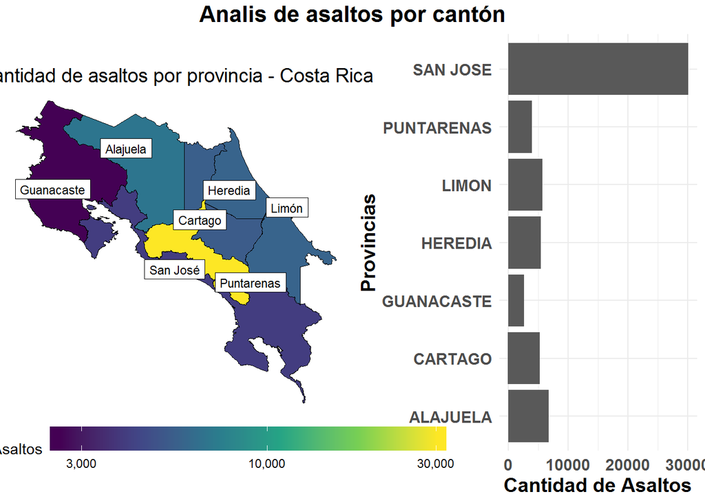

```r
library(forcats)
library(ggplot2)
library(dplyr)
library(sf)
library(scales)
library(ggplot2)
library(ggrepel)
library(egg)
library(grid)

OIJ2010 <- read.csv("OIJ_estadisticas_2010.csv", sep = ",")
OIJ2011 <- read.csv("OIJ_estadisticas_2011.csv", sep = ",")
OIJ2012 <- read.csv("OIJ_estadisticas_2012.csv", sep = ",")
OIJ2013 <- read.csv("OIJ_estadisticas_2013.csv", sep = ",")
OIJ2014 <- read.csv("OIJ_estadisticas_2014.csv", sep = ",")
OIJ2015 <- read.csv("OIJ_estadisticas_2015.csv", sep = ",")


provincias <- read_sf("geo_data/geo_data/provincias/provincias.shp")
asaltos <- rbind(OIJ2010, OIJ2011, OIJ2012, OIJ2013, OIJ2014, OIJ2015)
asaltos <- asaltos[-c(2,3,4,6,7,8,10,11,12)]
conteo_victimas <- count(asaltos, asaltos$SubVictima, asaltos$Provincia, name = "conteo")
asaltos_provincias <- count(asaltos, asaltos$Delito, asaltos$Provincia, name = "conteo")
mapa_asaltos <- left_join(x = provincias, y = asaltos_provincias, by = c("prov_nom1" = "asaltos$Provincia"))
centros <- st_centroid(provincias)
provincias <- cbind(provincias, st_coordinates(st_centroid(centros$geometry)))



g1 <- ggplot(mapa_asaltos, mapping = aes(fill = conteo)) +
  geom_sf(color = "black", size = .1) +
  geom_label_repel(mapping = aes(x = provincias$X, y = provincias$Y, label = paste(mapa_asaltos$prov_nom2)),
    size = 3, fill = "white", label.r = 0) +
  theme_void() +
  scale_fill_viridis_c(labels = comma,
                       trans = "log10",
                       name = "Cantidad de Asaltos",
                       direction = 1) +
  labs(title = "Cantidad de asaltos por provincia - Costa Rica") +
  theme(legend.position = "bottom", legend.key.width = unit(2,"cm"),
        plot.title = element_text(hjust = .5, size = 14))



g2 <- ggplot(data = conteo_victimas,
             mapping = aes(y = conteo_victimas$conteo,
                           x = conteo_victimas$`asaltos$Provincia`)) +
  geom_col() +
  coord_flip() +
  theme_minimal() +
  labs(x = "Provincias", y = "Cantidad de Asaltos") +
  theme(text = element_text(size = 14, face = "bold"))


gl <- list(g1, g2)
grid.arrange(grobs = gl,
             nrow = 1,
             widths = c(2,2),
             layout_matrix = rbind(c(1, 2),c(1, 2)),
             top = textGrob("Analis de asaltos por cantón", gp = gpar(fontface = 2, fontsize = 16),
                            hjust = 0.5, x = 0.5)
)
```

# 4. [30 puntos] Imagine que se le solicita realizar un informe sobre la violencia domestica en Costa Rica, utilizando los datos de las tablas violencia.csv desarrolle como minimo 4 graficos que le permitan representar e interpretar el fenomeno y su evolucion durante los ultimos a~nos, realice el trabajo tomando en cuenta que este debe estar pensado para su publicacion.

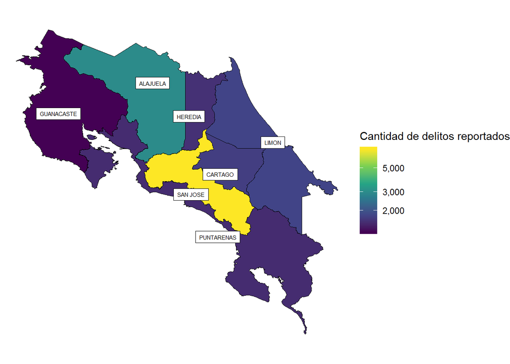

```r
library(forcats)
library(ggplot2)
library(dplyr)
library(sf)
library(scales)
library(ggplot2)
library(ggrepel)
library(egg)
library(grid)


datos_violencia <- read.csv("violencia.csv", sep = ";")
names(datos_violencia)[1] <- "Provincia"
names(datos_violencia)[2] <- "Canton"

to_upper <- function(x) toupper(chartr("áéíóúÁÉÍÓÚ", "aeiouAEIOU", x))
datos_violencia$Provincia <- to_upper(datos_violencia$Provincia)
datos_violencia$Canton <- to_upper(datos_violencia$Canton)
datos_violencia$Distrito <- to_upper(datos_violencia$Distrito)



provincias <- read_sf("geo_data/geo_data/provincias/provincias.shp")
cantones <- read_sf("geo_data/geo_data/cantones/cantones.shp")
distritos <- read_sf("geo_data/geo_data/distritos/distritos.shp")

#AÑOS
violencia_Provincia_2016 <- datos_violencia[c(1,4)]
violencia_Provincia_2016 <- na.omit(violencia_Provincia_2016);names(violencia_Provincia_2016)[2] <- "Total"
violencia_Provincia_2017 <- datos_violencia[c(1,5)]
violencia_Provincia_2017 <- na.omit(violencia_Provincia_2017);names(violencia_Provincia_2017)[2] <- "Total"
violencia_Provincia_2018 <- datos_violencia[c(1,6)]
violencia_Provincia_2018 <- na.omit(violencia_Provincia_2018);names(violencia_Provincia_2018)[2] <- "Total"

violencia_Canton_2016 <- datos_violencia[c(2,4)]
violencia_Canton_2016 <- na.omit(violencia_Canton_2016);names(violencia_Canton_2016)[2] <- "Total"
violencia_Canton_2017 <- datos_violencia[c(2,5)]
violencia_Canton_2017 <- na.omit(violencia_Canton_2017);names(violencia_Canton_2017)[2] <- "Total"
violencia_Canton_2018 <- datos_violencia[c(2,6)]
violencia_Canton_2018 <- na.omit(violencia_Canton_2018);names(violencia_Canton_2018)[2] <- "Total"

violencia_Distrito_2016 <- datos_violencia[c(3,4)]
violencia_Distrito_2016 <- na.omit(violencia_Distrito_2016);names(violencia_Distrito_2016)[2] <- "Total"
violencia_Distrito_2017 <- datos_violencia[c(3,5)]
violencia_Distrito_2017 <- na.omit(violencia_Distrito_2017);names(violencia_Distrito_2017)[2] <- "Total"
violencia_Distrito_2018 <- datos_violencia[c(3,6)]
violencia_Distrito_2018 <- na.omit(violencia_Distrito_2018);names(violencia_Distrito_2018)[2] <- "Total"

#BIND
total_Provincia <- bind_rows(violencia_Provincia_2016,violencia_Provincia_2017,violencia_Provincia_2018)
total_Canton <- bind_rows(violencia_Canton_2016,violencia_Canton_2017,violencia_Canton_2018)
total_Distrito<- bind_rows(violencia_Distrito_2016,violencia_Distrito_2017,violencia_Distrito_2018)



#SUMA
sum_provincia <- aggregate(total_Provincia$Total,
                           by=list(Provincia=total_Provincia$Provincia), FUN=sum)

sum_Canton <- aggregate(total_Canton$Total,
                           by=list(Canton=total_Canton$Canton), FUN=sum)

sum_Distrito <- aggregate(total_Distrito$Total,
                           by=list(Distrito=total_Distrito$Distrito), FUN=sum)



#JOIN
provincias_violencia <- left_join(x = provincias, y = sum_provincia, by = c("prov_nom1" = "Provincia"))
cantones_violencia <- left_join(x = cantones, y = sum_Canton, by = c("cant_nom1" = "Canton"))
distritos_violencia <- left_join(x = distritos, y = sum_Distrito, by = c("dist_nom1" = "Distrito"))



#CREACION DE CENTROS
centrosP <- st_centroid(provincias_violencia)
provincias_violencia <- cbind(provincias_violencia, st_coordinates(st_centroid(centrosP$geometry)))

centrosC <- st_centroid(cantones_violencia)
cantones_violencia <- cbind(cantones_violencia, st_coordinates(st_centroid(centrosC$geometry)))

centrosD <- st_centroid(distritos_violencia)
distritos_violencia <- cbind(distritos_violencia, st_coordinates(st_centroid(centrosD$geometry)))

## GRAFICOS
ggplot(provincias_violencia, mapping = aes(fill = x)) +
  geom_sf(color = "black", size = .1)+
  # Agregamo las etiquetas
  geom_label_repel(
    mapping = aes(x = provincias_violencia$X, y = provincias_violencia$Y,
                  label = provincias_violencia$prov_nom1),
    size = 2,
    fill = "white",
    label.r = 0) +
  theme_void() +
  # Modificamos la pelate de color
  scale_fill_viridis_c(labels = comma,
                       trans = "log10",
                       name = "Cantidad de delitos reportados",
                       direction = 1)
```

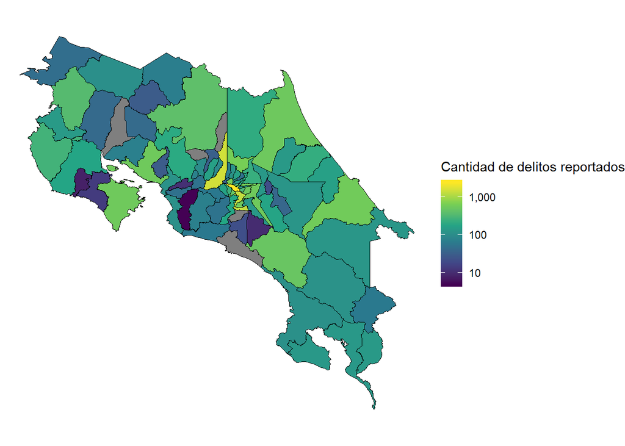

```r
ggplot(cantones_violencia, mapping = aes(fill = x)) +
  geom_sf(color = "black", size = .1)+
  # Agregamo las etiquetas
  # geom_label_repel(
  #   mapping = aes(x = cantones_violencia$X, y = cantones_violencia$Y,
  #                 label = cantones_violencia$prov_nom1),
  #   size = 2,
  #   fill = "white",
  #   label.r = 0) +
  theme_void() +
  # Modificamos la pelate de color
  scale_fill_viridis_c(labels = comma,
                       trans = "log10",
                       name = "Cantidad de delitos reportados",
                       direction = 1)
```

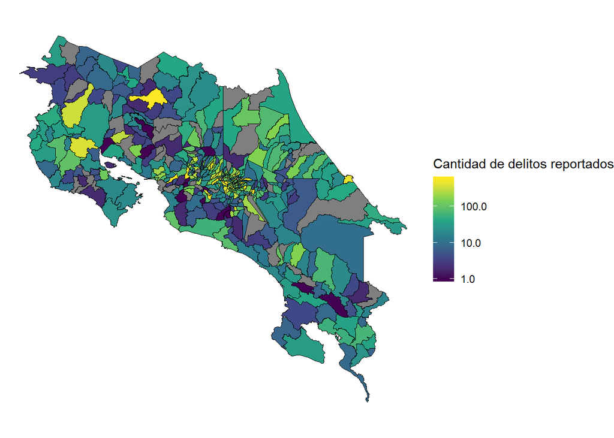

```r
ggplot(distritos_violencia, mapping = aes(fill = x)) +
  geom_sf(color = "black", size = .1)+
  # Agregamo las etiquetas
  # geom_label_repel(
  #   mapping = aes(x = cantones_violencia$X, y = cantones_violencia$Y,
  #                 label = cantones_violencia$prov_nom1),
  #   size = 2,
  #   fill = "white",
  #   label.r = 0) +
  theme_void() +
  # Modificamos la pelate de color
  scale_fill_viridis_c(labels = comma,
                       trans = "log10",
                       name = "Cantidad de delitos reportados",
                       direction = 1)
```

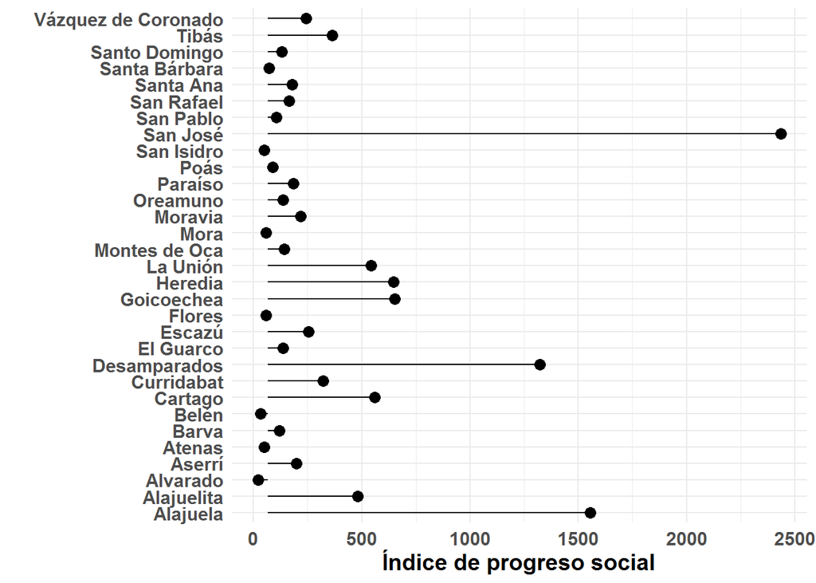

```r
GAM <- c("San José", "Escazú", "Desamparados", "Aserrí",
         "Mora", "Goicoechea", "Santa Ana", "Alajuelita",
         "Vázquez de Coronado", "Tibás", "Moravia","Montes de Oca" ,
         "Curridabat","Heredia", "Barva", "Santo Domingo",
         "Santa Bárbara", "San Rafael", "San Isidro", "Belén",
         "Flores", "San Pablo","Cartago", "Paraíso", "La Unión",
         "Alvarado", "Oreamuno" , "El Guarco","Alajuela","Atenas",
         "Poás")
mapa_GAM <- subset(cantones_violencia, cantones_violencia$cant_nom2 %in% GAM)

ggplot(data = mapa_GAM,mapping = aes(y = mapa_GAM$cant_nom2,
                                     x = mapa_GAM$x)) +
  geom_point(size = 3) +
  geom_segment(aes(x = 68,
                   y = cant_nom2,
                   xend = x,
                   yend = cant_nom2)) +

  theme_minimal() +
  labs(x = "Índice de progreso social", y = "") +
  theme(text = element_text(size = 14, face = "bold"))
```